# Übungsaufgabe 01: Signaldarstellung

Schreibe ein Programm, welches gegebene Signale grafisch darstellt.

Ein einfaches Signal ist definiert durch Amplitude $A$, Frequenz $f$ und Phasenverschiebung $\varphi$. Das Signal $y$ berechnet sich basierend auf der Variablen $t$ laut folgender Formel:

$y = A \cdot \sin(2\pi \cdot f \cdot t + \varphi)$

Gegeben ist eine Datei `signals.txt`, welche Amplituden, Frequenzen (in Hz), Phasenverschiebungen (**in Grad**, Umrechnung in Radiant: $rad = deg \cdot \frac{\pi}{180}$) und Farben für **drei Signale** enthält:

```
amplitudes=10,15,20
frequencies=5,2,1
phases=180,90,0
colors=blue,red,green
```

Schreibe eine Funktion `readSignals(fileName)`, welche die Datei mit dem übergebenen Dateinamen einliest und den Inhalt in ein **dict** speichert. Als Keys sollen die Bezeichnungen links des Gleichzeichens verwendet werden. Die Werte rechts davon sollen jeweils zum entsprechenden Key als Liste in das **dict** gespeichert werden. Die Funktion gibt das **dict** zurück.

Außerdem ist eine weitere Datei `noise.txt` gegeben. Diese kann einfach mittels der Numpy-Funktion `loadtxt()` als **Matrix** eingelesen werden. Die Datei enthält **vier Spalten**: Zeit $t$ in Sekunden, Rauschen für Signal 1, Rauschen für Signal 2, Rauschen für Signal 3

```
   0.000    0.230    0.569   -0.895
   0.010   -1.246    3.499    7.771
   0.020   -0.358    0.391    1.187
   0.030    1.168    0.073    5.976
   ...
```

Schreibe eine Funktion `plotSignal(axes, signals, noise, index)`, welche ein Signal in die übergebenen Achsen plottet. Der Funktion soll außerdem das **dict** mit den Signalen, die **Numpy-Matrix** mit dem Rauschen und ein **Index** für das darzustellende Signal übergeben werden.

Die Funktion soll zum einen das Signal mit dem gegebenen Index, welches sich über obige Formel berechnen lässt, als Linie mit der entsprechenden Farbe dargestellt werden. Für das Signal soll ein passender Legendeneintrag angelegt werden, in dem die **Amplitude, Frequenz und Phase** enthalten sind. Zusätzlich soll das Rauschen des entsprechenden Signals auf das Signal addiert und das Ergebnis als Punkte dargestellt werden.

Mit der Funktion `plotSignal()` sollen die drei Signale in eine **Figur (Breite: 10, Höhe: 5)** geplottet werden. Anschließend soll die Figur als Datei `signals.png` mit **300 DPI** gespeichert werden.

Achte darauf, dass die Zeitachse korrekt **beschriftet** und auf den gegebenen **Zeitraum eingeschränkt** ist.

Das Ergebnis soll folgendermaßen aussehen:

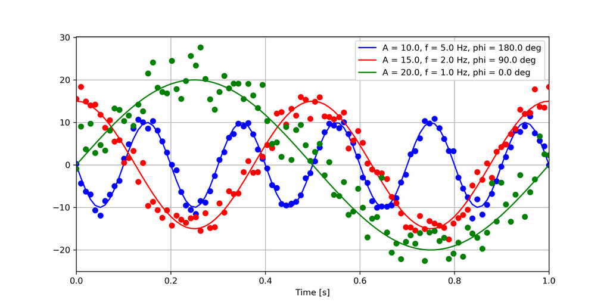

### Abgabe

Im [TeachCenter](https://tc.tugraz.at/main/course/view.php?id=938) bis zur nächsten Einheit.

Lade ein Archiv `ex01Signals.zip` mit allen Dateien vor der nächsten Vorlesung (13:00 Uhr) im Abgabebereich der entsprechenden Aufgabe hoch.